# Biostat 216 Homework 5

Due Nov 15 @ 11:59pm

Submit a PDF (scanned/photographed from handwritten solutions, or converted from RMarkdown or Jupyter Notebook or Quarto) to Gradescope in BruinLearn.

## 1 Q1

Let $\mathbf{A} \in \mathbb{R}^{m \times n}$. Show the following properties of generalized inverses.

1. For any generalized inverse $\mathbf{A}^-$, $\text{rank}(\mathbf{A}^-) \ge \text{rank}(\mathbf{A})$.
2. $\text{rank}(\mathbf{A}^+) = \text{rank}(\mathbf{A})$.
3. $(\mathbf{A}^-)'$ is a generalized inverse of $\mathbf{A}'$.
4. $(\mathbf{A}^+)' = (\mathbf{A}')^+$.

## 2 Q2 Householder algorithm for QR factorization

Let $\mathbf{v} \in \mathbb{R}^n$. Define the **Householder reflection matrix**
$$\mathbf{H} = \mathbf{I} - 2 \frac{\mathbf{v} \mathbf{v}'}{\|\mathbf{v}\|^2} = \mathbf{I} - 2 \mathbf{u} \mathbf{u}',$$
where $\mathbf{u}$ is the unit vector $\mathbf{v} / \|\mathbf{v}\|$.

1. Show that $\mathbf{H}$ is symmetric and orthogonal.
2. Let $\mathbf{a}, \mathbf{b} \in \mathbb{R}^n$ such that $\|\mathbf{a}\| = \|\mathbf{b}\|$. Find a Householder matrix such that $\mathbf{H} \mathbf{a} = \mathbf{b}$.
3. Let $\mathbf{a} \in \mathbb{R}^n$ be a non-zero vector. Find a Householder matrix such that
   $$\mathbf{H} \mathbf{a} = \begin{pmatrix} \|\mathbf{a}\| \\ \mathbf{0}_{n-1} \end{pmatrix}.$$
4. Let $\mathbf{a} \in \mathbb{R}^n$. Find a Householder matrix such that
   $$\mathbf{H} \mathbf{a} = \begin{pmatrix} a_1 \\ \|\mathbf{a}_{2:n}\| \\ \mathbf{0}_{n-2} \end{pmatrix}.$$
5. Let $\mathbf{A} \in \mathbb{R}^{n \times p}$. Describe how to find a sequence of Householder matrices $\mathbf{H}_1, \ldots, \mathbf{H}_{p}$ such that
   $$\mathbf{H}_{p} \mathbf{H}_{p-1} \cdots \mathbf{H}_1 \mathbf{A} = \mathbf{R},$$
   where $\mathbf{R} \in \mathbb{R}^{n \times p}$ is an upper triangular matrix.
6. Describe how this generates a full QR decomposition of matrix $\mathbf{A} = \mathbf{Q} \mathbf{R}$, where $\mathbf{Q} \in \mathbb{R}^{n \times n}$ is an orthogonal matrix and $\mathbf{R}$ is upper triangular.

## 3 Q3

1. For any $\mathbf{X} \in \mathbb{R}^{n \times p}$ and $\mathbf{y} \in \mathbb{R}^n$, show that the normal equation
   $$\mathbf{X}' \mathbf{X} \boldsymbol{\beta} = \mathbf{X}' \mathbf{y}$$
   always has at least one solution.
2. Show that $(\mathbf{A}' \mathbf{A})^- \mathbf{A}'$ is a generalized inverse of $\mathbf{A}$.
3. $\mathbf{P}_{\mathbf{A}} = \mathbf{A} (\mathbf{A}' \mathbf{A})^- \mathbf{A}'$ is the orthogonal projector onto $\mathcal{C}(\mathbf{A})$.

## 4 Q4 Missile tracking

A missile is fired from enemy territory, and its position in flight is observed by radar tracking devices at the following positions.

| $x$=Position down range (1000 miles) | 0 | 0.25 | 0.5 | 0.75 | 1 |
| --- | --- | --- | --- | --- | --- |
| $y$=Height (1000 miles) | 0 | 0.008 | 0.015 | 0.019 | 0.020 |

Suppose that intelligence sources indicate that enemy missiles are programmed to follow a parabolic flight path: $y = f(x) = \alpha_0 + \alpha_1 x + \alpha_2 x^2$. Where is the missile expected to land? Hint: You can find the solution using computer program. For example, in Julia, least squares solution is obtained by command `A \ b`.

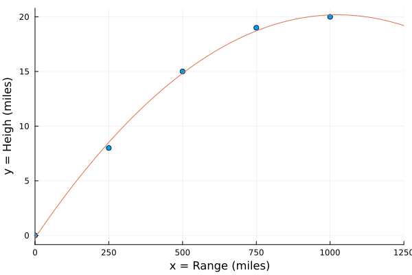

## 5 BV exercises

12.2, 12.4, 12.8